# Leapfrog2 - Dynamic mapping of Early farming

T. Huet

7/22/2020

# Presentation of ‘Leapfrog2’ app

The structure of the `leapfrog2` app was created in the framework of the french [ANR CIMO](https://www.cepam.cnrs.fr/sites/cimo/) project, under the direction of Didier Binder ([CEPAM-CNRS](https://www.cepam.cnrs.fr)).

The app first version (`leapfrog`) is a standalone one which simulate a GIS interface to facilitate the updating of a worksheet grouping data on first farming sites across Italy and Southern France. At the present time this important dataset is under revision. Therefore, I have adapted the structure of the RShiny app to read my own data. These latter are only here as a training set.

`leapfrog2` URL is https://epispat.shinyapps.io/leapfrog2/

## Window ‘map’

This first window need to be refresh by moving the chronological slider.

[figure not shown]

The upper part of the window shows a [OSM](https://www.openstreetmap.org/) basemap handle in RShiny by [`leaflet`](https://leafletjs.com/), the bottom part of the window show the listing of the features which appear on the map (the others are hided)

To get information on a feature, click on this feature.

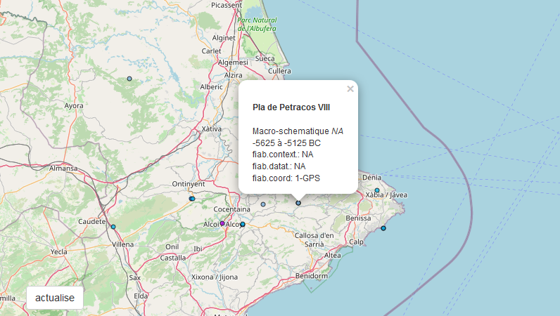

To get a lat / long position on the map, clik on the position. OSM map give precious and precise information on the geographical situation of various ‘important’ places, caves, shelter, etc.

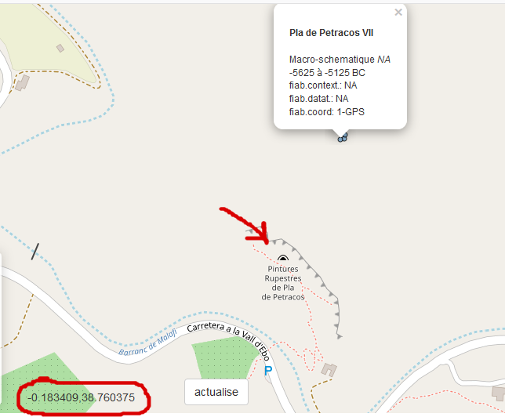

The *Actualise* button is only working in the standalone app (actualy `leapfrog`) .

## Window ‘data’

The second windows present the whole dataset with various search and order tools.

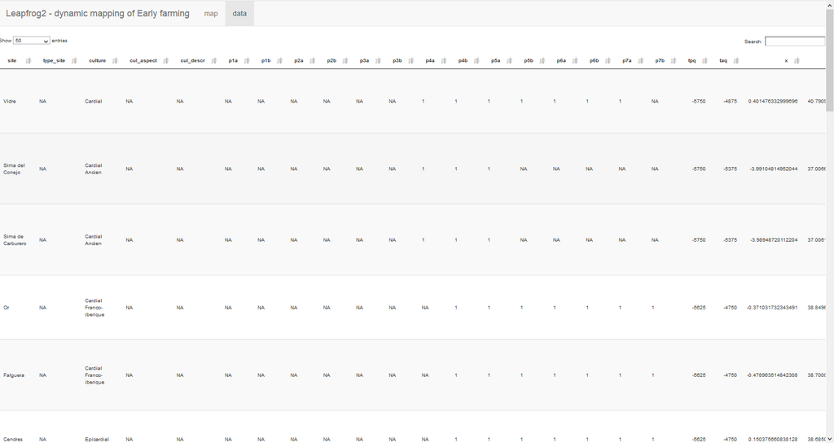